# HUPS2

Chris Harris

Last edited: 11 May, 2020

## Summary

[Here](https://www.soscisurvey.de/hups2/?act=6V57JPRSRHTwggCGuPqrFBGy) is a current link to the pretest. This pretest version allows you to skip pages by using that yellow bar in the top. Make sure to definitely visit the second page on which all parameters get initialized.

We had two conditions, one with many smiles one with many frowns.

We counterbalanced whether participants saw two males or two females, which of two pairs (two pairs for each gender) they saw, who was shown left and who was shown right, and finally whether the left or the right person was the person shown more frequently.

The distribution participants encountered was for the smiles condition:

|  | Smiles | Frowns |
| --- | --- | --- |
| Person A | 9 | 3 |
| Person B | 3 | 1 |

For the frowns condition it was

|  | Smiles | Frowns |
| --- | --- | --- |
| Person A | 3 | 9 |
| Person B | 1 | 3 |

After a short introduction (“In this study, we investigate how people form impressions of others. You will encounter two individuals a few times and then we will ask you some questions regarding these two individuals.”), participants encountered the initial evidence, and then answered a number of DVs (the other tabs). The order of the tabs is also the order the DVs were asked. I tried to give an indication of what each DV looked like, but participants either had a binary choice in which they clicked on either of the two images. Or they cound indicate their estimate on a slider with the two images as anchors.

## Likeability

*Who of these two would you rather be around for an evening?*

(image left) (image right)

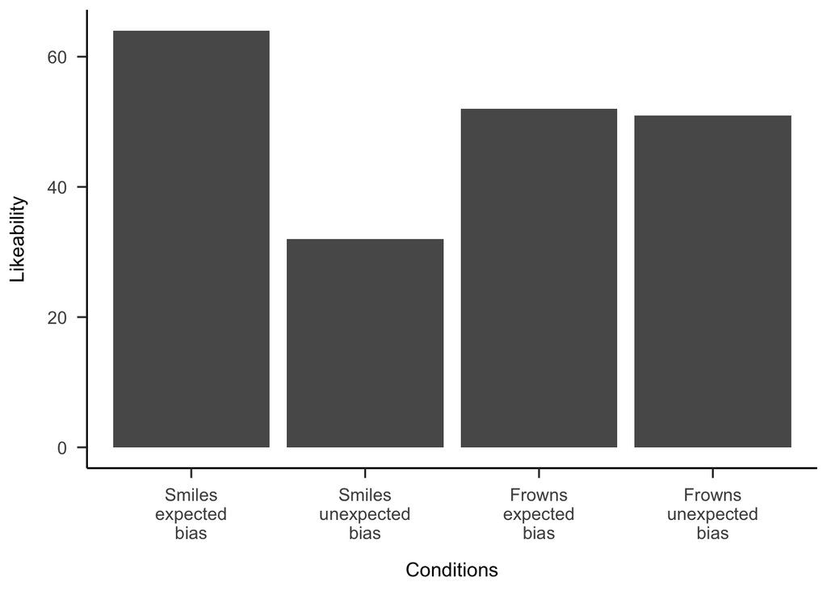

```r
df2 %>%
  mutate(like_cond = case_when(condition == "smiles" & like == 1 ~ "Smiles\nexpected\nbias",
                               condition == "smiles" & like == -1 ~ "Smiles\nunexpected\nbias",
                               condition == "frowns" & like == 1 ~ "Frowns\nexpected\nbias",
                               condition == "frowns" & like == -1 ~ "Frowns\nunexpected\nbias")) %>%
  mutate(like_cond = factor(like_cond, levels = c("Smiles\nexpected\nbias",
                                                  "Smiles\nunexpected\nbias",
                                                  "Frowns\nexpected\nbias",
                                                  "Frowns\nunexpected\nbias"))) %>%
  ggplot(aes(x = like_cond)) +
  geom_bar() +
  theme_apa() +
  labs(x = "Conditions",
       y = "Likeability") +
  theme(legend.position = "none")
```

```r
df2 %>%
  mutate(like = factor(like, levels = c(-1, 1), labels = c("unexpected", "expected"))) %$%
  table(condition, like) %>%
  knitr::kable(caption = "Descriptives likeability", digits = 2) %>%
  kable_styling(bootstrap_options = "hover", full_width = F, position = "center")
```

Descriptives likeability

|  | unexpected | expected |
| --- | --- | --- |
| smiles | 32 | 64 |
| frowns | 51 | 52 |

Smiles

```r
# Distribution
distr_like <- df2 %>%
  mutate(like = ifelse(like == 1, 1, 0)) %$%
  table(like, condition)
distr_like
```

```
##     condition
## like smiles frowns
##    0     32     51
##    1     64     52
```

```r
# Tests
# Smiles
proportionBF(y = distr_like["1", "smiles"],
             N = distr_like["1", "smiles"] + distr_like["0", "smiles"],
             p = .5,
             rscale = "ultrawide",
             nullInterval = c(.5, 1)) %>% printBFb()
```

```
## [1] "BF+0 = 54.97"
```

```r
binom.test(x = distr_like["1", "smiles"],
           n = distr_like["1", "smiles"] + distr_like["0", "smiles"],
           p = .5,
           alternative = "greater")
```

```
##
##  Exact binomial test
##
## data:  distr_like["1", "smiles"] and distr_like["1", "smiles"] + distr_like["0", "smiles"]
## number of successes = 64, number of trials = 96, p-value = 0.0007122
## alternative hypothesis: true probability of success is greater than 0.5
## 95 percent confidence interval:
##  0.5791783 1.0000000
## sample estimates:
## probability of success
##              0.6666667
```

Frowns

```r
# Frowns
proportionBF(y = distr_like["1", "frowns"],
             N = distr_like["1", "frowns"] + distr_like["0", "frowns"],
             p = .5,
             rscale = "ultrawide",
             nullInterval = c(.5, 1)) %>% printBFb()
```

```
## [1] "BF+0 = 0.13"
```

```r
binom.test(x = distr_like["1", "frowns"],
           n = distr_like["1", "frowns"] + distr_like["0", "frowns"],
           p = .5,
           alternative = "greater")
```

```
##
##  Exact binomial test
##
## data:  distr_like["1", "frowns"] and distr_like["1", "frowns"] + distr_like["0", "frowns"]
## number of successes = 52, number of trials = 103, p-value = 0.5
## alternative hypothesis: true probability of success is greater than 0.5
## 95 percent confidence interval:
##  0.4196862 1.0000000
## sample estimates:
## probability of success
##              0.5048544
```

## Preference

*Which of these two persons did you like more?*

(image left) |———–| (image right)

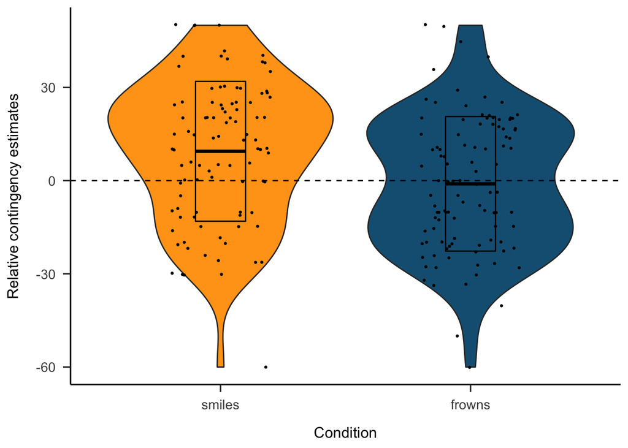

```r
# Graph
df2 %>%
  ggplot(aes(x = condition,
             y = pref,
             fill = condition)) +
  geom_violin() +
  stat_summary(fun.data = "mean_sdl", geom = "crossbar", width = 0.2, fun.args = list(mult = 1)) +
  geom_jitter(size = 0.5, width = 0.2) +
  geom_hline(yintercept = 0, linetype = 2) +
  scale_fill_manual(values = pal) +
  theme_apa() +
  labs(x = "Condition",
       y = "Relative contingency estimates") +
  theme(legend.position = "none")
```

```r
### Descriptives
df2 %>%
  group_by(condition) %>%
  summarize(M = printnum(mean(pref)),
            SD = printnum(sd(pref))) %>%
  knitr::kable(caption = "Descriptives preference", digits = 2) %>%
  kable_styling(bootstrap_options = "hover", full_width = F, position = "center")
```

Descriptives preference

| condition | M | SD |
| --- | --- | --- |
| smiles | 9.44 | 22.51 |
| frowns | -1.03 | 21.66 |

Smiles

```r
# Smiles
df2 %>%
  filter(condition == "smiles") %>%
  as.data.frame() %$%
  ttestBF(pref,
          mu = 0,
          nullInterval = c(0, Inf)) %>%
  printBFt()
```

```
## [1] "BF+0 = 436.84, d = 0.41, 95% HDI [0.20, 0.62]"
```

```r
ttest(data = df2,
      y = pref,
      x = condition,
      mu = 0,
      sub = "smiles",
      dir = "greater")
```

```
## [1] "t(95) = 4.11, p < .001, d = 0.42, 95% CI [0.21, 0.63]"
```

Frowns

```r
# Frowns
df2 %>%
  filter(condition == "frowns") %>%
  as.data.frame() %$%
  ttestBF(pref,
          mu = 0,
          nullInterval = c(0, Inf)) %>%
  printBFt()
```

```
## [1] "BF+0 = 0.08, d = -0.05, 95% HDI [-0.23, 0.15]"
```

```r
ttest(data = df2,
      y = pref,
      x = condition,
      mu = 0,
      sub = "frowns",
      dir = "greater")
```

```
## [1] "t(102) = -0.48, p = .685, d = -0.05, 95% CI [-0.24, 0.15]"
```

Strength

```r
# Strength
df2 %>%
  as.data.frame() %>%
  ttestBF(formula = pref ~ condition,
          nullInterval = c(-Inf, Inf),
          data = .) %>%
  printBFt()
```

```
## [1] "BF10 = 26.12, d = 0.45, 95% HDI [0.17, 0.73]"
```

```r
ttest(data = df2,
      y = pref,
      x = condition,
      dir = "two.sided")
```

```
## [1] "t(194.68) = 3.34, p = .001, d = 0.47, 95% CI [0.19, 0.76]"
```

Overall

```r
## Overall
df2 %>%
  as.data.frame() %$%
  ttestBF(pref,
          mu = 0,
          nullInterval = c(0, Inf)) %>%
  printBFt()
```

```
## [1] "BF+0 = 3.32, d = 0.17, 95% HDI [0.03, 0.31]"
```

```r
ttest(data = df2,
      y = pref,
      x = condition,
      mu = 0,
      dir = "greater")
```

```
## [1] "t(198) = 2.51, p = .007, d = 0.18, 95% CI [0.04, 0.32]"
```

## Employability

*Imagine you are responsible for a small team of employees. Who would you rather hire?*

(image left) (image right)

There is a 100% match between the two dichotomous variables (likeability and employability), *r* = 1.

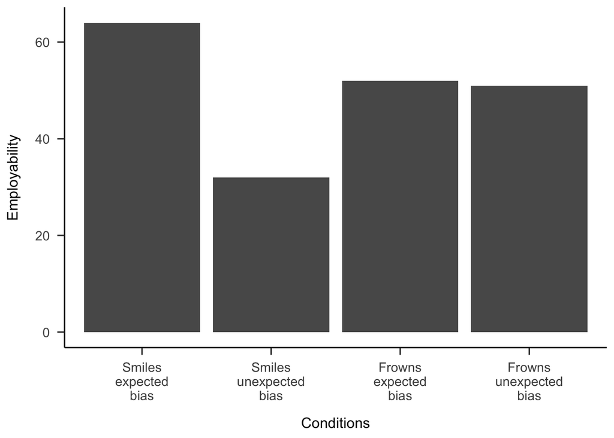

```r
df2 %>%
  mutate(empl_cond = case_when(condition == "smiles" & like == 1 ~ "Smiles\nexpected\nbias",
                               condition == "smiles" & like == -1 ~ "Smiles\nunexpected\nbias",
                               condition == "frowns" & like == 1 ~ "Frowns\nexpected\nbias",
                               condition == "frowns" & like == -1 ~ "Frowns\nunexpected\nbias")) %>%
  mutate(empl_cond = factor(empl_cond, levels = c("Smiles\nexpected\nbias",
                                                  "Smiles\nunexpected\nbias",
                                                  "Frowns\nexpected\nbias",
                                                  "Frowns\nunexpected\nbias"))) %>%
  ggplot(aes(x = empl_cond)) +
  geom_bar() +
  theme_apa() +
  labs(x = "Conditions",
       y = "Employability") +
  theme(legend.position = "none")
```

```r
df2 %>%
  mutate(empl = factor(empl, levels = c(-1, 1), labels = c("unexpected", "expected"))) %$%
  table(condition, empl) %>%
  knitr::kable(caption = "Occurences Employability", digits = 2) %>%
  kable_styling(bootstrap_options = "hover", full_width = F, position = "center")
```

Occurences Employability

|  | unexpected | expected |
| --- | --- | --- |
| smiles | 32 | 64 |
| frowns | 51 | 52 |

Smiles

```r
## Binary
# Distribution
distr_empl <- df2 %>%
  mutate(empl = ifelse(empl == 1, 1, 0)) %$%
  table(empl, condition)

# Tests
proportionBF(y = distr_empl["1", "smiles"],
             N = distr_empl["1", "smiles"] + distr_empl["0", "smiles"],
             p = .5,
             rscale = "ultrawide",
             nullInterval = c(.5, 1)) %>% printBFb()
```

```
## [1] "BF+0 = 54.97"
```

```r
binom.test(x = distr_empl["1", "smiles"],
           n = distr_empl["1", "smiles"] + distr_empl["0", "smiles"],
           p = .5,
           alternative = "greater")
```

```
##
##  Exact binomial test
##
## data:  distr_empl["1", "smiles"] and distr_empl["1", "smiles"] + distr_empl["0", "smiles"]
## number of successes = 64, number of trials = 96, p-value = 0.0007122
## alternative hypothesis: true probability of success is greater than 0.5
## 95 percent confidence interval:
##  0.5791783 1.0000000
## sample estimates:
## probability of success
##              0.6666667
```

Frowns

```r
proportionBF(y = distr_empl["1", "frowns"],
             N = distr_empl["1", "frowns"] + distr_empl["0", "frowns"],
             p = .5,
             rscale = "ultrawide",
             nullInterval = c(.5, 1)) %>% printBFb()
```

```
## [1] "BF+0 = 0.13"
```

```r
binom.test(x = distr_empl["1", "frowns"],
           n = distr_empl["1", "frowns"] + distr_empl["0", "frowns"],
           p = .5,
           alternative = "greater")
```

```
##
##  Exact binomial test
##
## data:  distr_empl["1", "frowns"] and distr_empl["1", "frowns"] + distr_empl["0", "frowns"]
## number of successes = 52, number of trials = 103, p-value = 0.5
## alternative hypothesis: true probability of success is greater than 0.5
## 95 percent confidence interval:
##  0.4196862 1.0000000
## sample estimates:
## probability of success
##              0.5048544
```

## Impression

*On average, did this person seem more grumpy or more cheerful most of the time?*

Left : Grumpy |———-| Cheerful  
Right: Grumpy |———-| Cheerful

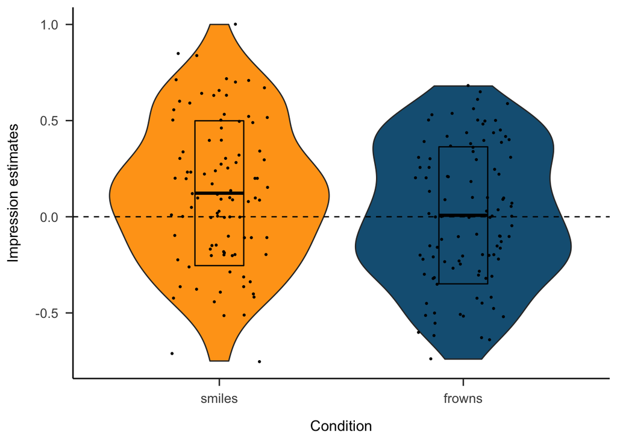

```r
# Graph
df2 %>%
  ggplot(aes(x = condition,
             y = impr_dp,
             fill = condition)) +
  geom_violin() +
  stat_summary(fun.data = "mean_sdl", geom = "crossbar", width = 0.2, fun.args = list(mult = 1)) +
  geom_jitter(size = 0.5, width = 0.2) +
  geom_hline(yintercept = 0, linetype = 2) +
  scale_fill_manual(values = pal) +
  theme_apa() +
  labs(x = "Condition",
       y = "Impression estimates") +
  theme(legend.position = "none")
```

```r
### Descriptives
df2 %>%
  group_by(condition) %>%
  summarize(M = printnum(mean(impr_dp)),
            SD = printnum(sd(impr_dp))) %>%
  knitr::kable(caption = "Descriptives impression", digits = 2) %>%
  kable_styling(bootstrap_options = "hover", full_width = F, position = "center")
```

Descriptives impression

| condition | M | SD |
| --- | --- | --- |
| smiles | 0.12 | 0.38 |
| frowns | 0.01 | 0.36 |

Smiles

```r
# Smiles
df2 %>%
  filter(condition == "smiles") %>%
  as.data.frame() %$%
  ttestBF(impr_dp,
          mu = 0,
          nullInterval = c(0, Inf)) %>%
  printBFt()
```

```
## [1] "BF+0 = 24.96, d = 0.32, 95% HDI [0.11, 0.52]"
```

```r
ttest(data = df2,
      y = impr_dp,
      x = condition,
      mu = 0,
      sub = "smiles",
      dir = "greater")
```

```
## [1] "t(95) = 3.19, p < .001, d = 0.33, 95% CI [0.12, 0.53]"
```

Frowns

```r
# Frowns
df2 %>%
  filter(condition == "frowns") %>%
  as.data.frame() %$%
  ttestBF(impr_dp,
          mu = 0,
          nullInterval = c(0, Inf)) %>%
  printBFt()
```

```
## [1] "BF+0 = 0.13, d = 0.02, 95% HDI [-0.17, 0.21]"
```

```r
ttest(data = df2,
      y = impr_dp,
      x = condition,
      mu = 0,
      sub = "frowns",
      dir = "greater")
```

```
## [1] "t(102) = 0.21, p = .416, d = 0.02, 95% CI [-0.17, 0.21]"
```

Strength

```r
# Strength
df2 %>%
  as.data.frame() %>%
  ttestBF(formula = impr_dp ~ condition,
          nullInterval = c(-Inf, Inf),
          data = .) %>%
  printBFt()
```

```
## [1] "BF10 = 1.51, d = 0.29, 95% HDI [0.02, 0.57]"
```

```r
ttest(data = df2,
      y = impr_dp,
      x = condition,
      dir = "two.sided")
```

```
## [1] "t(193.93) = 2.21, p = .028, d = 0.31, 95% CI [0.03, 0.60]"
```

Overall

```r
## Overall
df2 %>%
  as.data.frame() %$%
  ttestBF(impr_dp,
          mu = 0,
          nullInterval = c(0, Inf)) %>%
  printBFt()
```

```
## [1] "BF+0 = 2.60, d = 0.17, 95% HDI [0.03, 0.30]"
```

```r
ttest(data = df2,
      y = impr_dp,
      x = condition,
      mu = 0,
      dir = "greater")
```

```
## [1] "t(198) = 2.40, p = .009, d = 0.17, 95% CI [0.03, 0.31]"
```

## Conditional estimates

*How likely (in %) was it that if you encountered… ….XXX, they smiled?*

Left : 0 |———-| 100  
Right: 0 |———-| 100

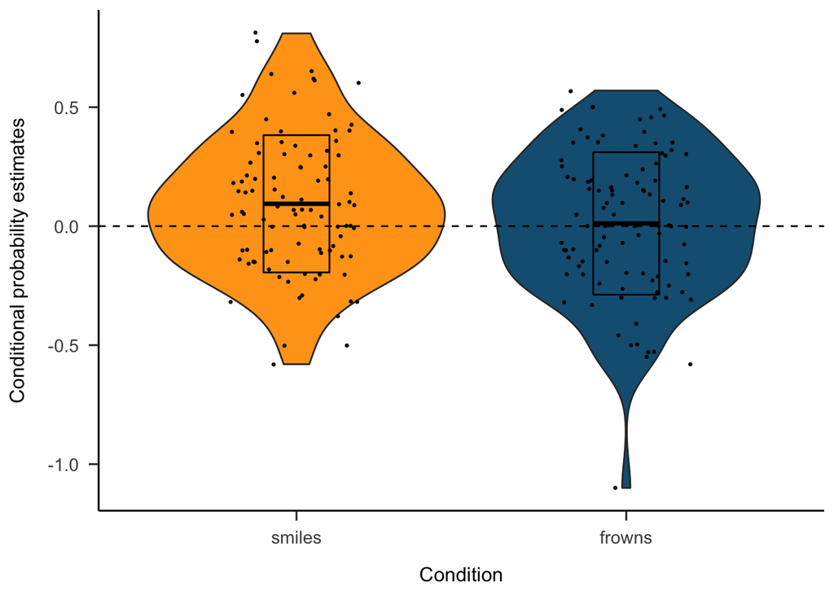

```r
df2 %>%
  ggplot(aes(x = condition,
             y = cond_dp,
             fill = condition)) +
  geom_violin() +
  stat_summary(fun.data = "mean_sdl", geom = "crossbar", width = 0.2, fun.args = list(mult = 1)) +
  geom_jitter(size = 0.5, width = 0.2) +
  geom_hline(yintercept = 0, linetype = 2) +
  scale_fill_manual(values = pal) +
  theme_apa() +
  labs(x = "Condition",
       y = "Conditional probability estimates") +
  theme(legend.position = "none")
```

```r
### Descriptives
df2 %>%
  group_by(condition) %>%
  summarize(M = printnum(mean(cond_dp)),
            SD = printnum(sd(cond_dp))) %>%
  knitr::kable(caption = "Conditional probability estimates", digits = 2) %>%
  kable_styling(bootstrap_options = "hover", full_width = F, position = "center")
```

Conditional probability estimates

| condition | M | SD |
| --- | --- | --- |
| smiles | 0.09 | 0.29 |
| frowns | 0.01 | 0.30 |

Smiles

```r
# Smiles
df2 %>%
  filter(condition == "smiles") %>%
  as.data.frame() %$%
  ttestBF(cond_dp,
          mu = 0,
          nullInterval = c(0, Inf)) %>%
  printBFt()
```

```
## [1] "BF+0 = 25.02, d = 0.32, 95% HDI [0.11, 0.51]"
```

```r
ttest(data = df2,
      y = cond_dp,
      x = condition,
      mu = 0,
      sub = "smiles",
      dir = "greater")
```

```
## [1] "t(95) = 3.19, p < .001, d = 0.33, 95% CI [0.12, 0.53]"
```

Frowns

```r
# Frowns
df2 %>%
  filter(condition == "frowns") %>%
  as.data.frame() %$%
  ttestBF(cond_dp,
          mu = 0,
          nullInterval = c(0, Inf)) %>%
  printBFt()
```

```
## [1] "BF+0 = 0.15, d = 0.04, 95% HDI [-0.15, 0.23]"
```

```r
ttest(data = df2,
      y = cond_dp,
      x = condition,
      mu = 0,
      sub = "frowns",
      dir = "greater")
```

```
## [1] "t(102) = 0.39, p = .349, d = 0.04, 95% CI [-0.15, 0.23]"
```

Strength

```r
# Strength
df2 %>%
  as.data.frame() %>%
  ttestBF(formula = cond_dp ~ condition,
          nullInterval = c(-Inf, Inf),
          data = .) %>%
  printBFt()
```

```
## [1] "BF01 = 1.05, d = 0.26, 95% HDI [-0.01, 0.54]"
```

```r
ttest(data = df2,
      y = cond_dp,
      x = condition,
      dir = "two.sided")
```

```
## [1] "t(196.77) = 1.98, p = .049, d = 0.28, 95% CI [0.00, 0.56]"
```

Overall

```r
## Overall
df2 %>%
  as.data.frame() %$%
  ttestBF(cond_dp,
          mu = 0,
          nullInterval = c(0, Inf)) %>%
  printBFt()
```

```
## [1] "BF+0 = 2.84, d = 0.17, 95% HDI [0.03, 0.31]"
```

```r
ttest(data = df2,
      y = cond_dp,
      x = condition,
      mu = 0,
      dir = "greater")
```

```
## [1] "t(198) = 2.44, p = .008, d = 0.17, 95% CI [0.03, 0.31]"
```

## Confidence

*How confident (in %) are you that you can make a reasonable estimate?*

Left : 0 |———-| 100  
Right: 0 |———-| 100

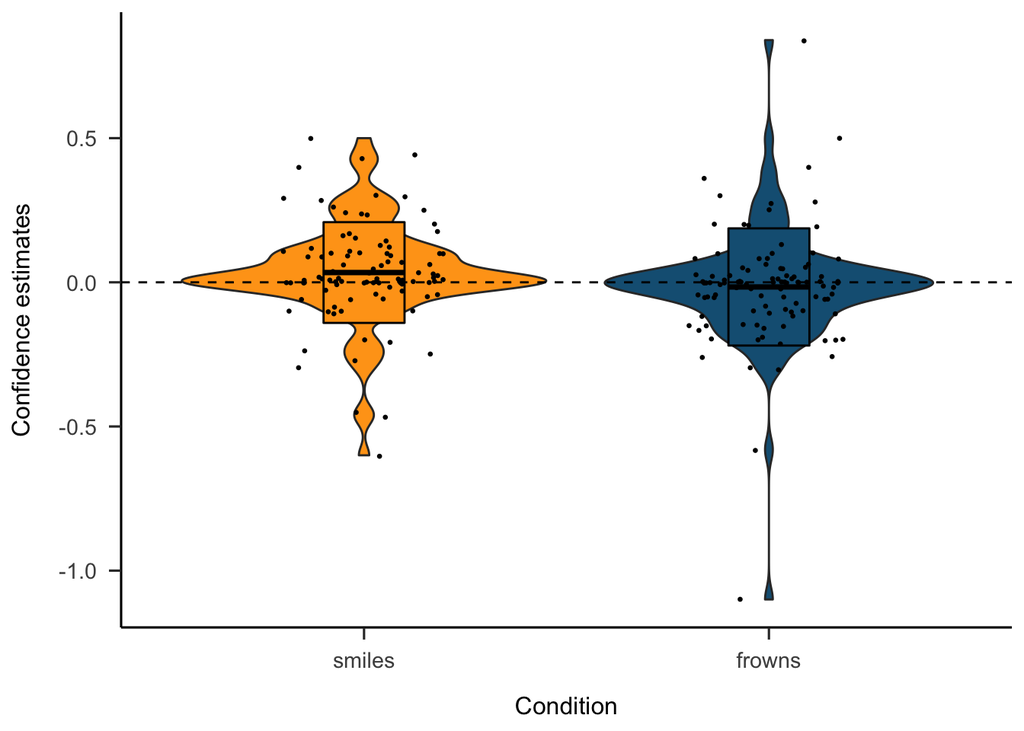

```r
# Graph
df2 %>%
  ggplot(aes(x = condition,
             y = conf_dp,
             fill = condition)) +
  geom_violin() +
  stat_summary(fun.data = "mean_sdl", geom = "crossbar", width = 0.2, fun.args = list(mult = 1)) +
  geom_jitter(size = 0.5, width = 0.2) +
  geom_hline(yintercept = 0, linetype = 2) +
  scale_fill_manual(values = pal) +
  theme_apa() +
  labs(x = "Condition",
       y = "Confidence estimates") +
  theme(legend.position = "none")
```

```r
### Descriptives
df2 %>%
  group_by(condition) %>%
  summarize(M = printnum(mean(conf_dp)),
            SD = printnum(sd(conf_dp))) %>%
  knitr::kable(caption = "Confidence estimates", digits = 2) %>%
  kable_styling(bootstrap_options = "hover", full_width = F, position = "center")
```

Confidence estimates

| condition | M | SD |
| --- | --- | --- |
| smiles | 0.03 | 0.17 |
| frowns | -0.02 | 0.20 |

```r
### Test
df2 %>%
  as.data.frame() %>%
  ttestBF(formula = conf_dp ~ condition,
          nullInterval = c(-Inf, Inf),
          data = .) %>%
  printBFt()
```

```
## [1] "BF01 = 1.31, d = 0.25, 95% HDI [-0.02, 0.52]"
```

```r
ttest(data = df2,
      y = conf_dp,
      x = condition,
      dir = "two.sided")
```

```
## [1] "t(195.74) = 1.86, p = .064, d = 0.26, 95% CI [-0.02, 0.54]"
```

## Demographic data

Our participants:

```r
# Summary of most relevant demographic data
df2 %>%
  summarise(N = n(),
            female = length(which(gender == "female")),
            age_mean = mean(age, na.rm = TRUE),
            age_sd = sd(age, na.rm = TRUE),
            Psychstudents_percent = length(which(psych == "Yes")) / n() * 100) %>%
  knitr::kable(caption = "Demographic data", digits = 2) %>%
  kable_styling(bootstrap_options = "hover", full_width = F, position = "center")
```

Demographic data

| N | female | age_mean | age_sd | Psychstudents_percent |
| --- | --- | --- | --- | --- |
| 199 | 79 | 28.01 | 7.97 | 7.04 |

And their level of education:

```r
# Level of education
df2 %>%
  group_by(edu) %>%
  summarise(count = length(edu)) %>%
  knitr::kable(caption = "LEvel of education", digits = 2) %>%
  kable_styling(bootstrap_options = "hover", full_width = F, position = "center")
```

LEvel of education

| edu | count |
| --- | --- |
| No formal education | 3 |
| Secondary school/GCSE | 39 |
| College/A levels | 44 |
| Undergraduate degree (BA, BSc or comparable) | 65 |
| Graduate degree (MA, MSc or comparable) | 42 |
| Doctorate degree (PhD, MD, or comparable) | 6 |

## Counterbalancing check

This tab is mainly for me to make sure I got the recoding of all the counterbalancing right.

Regression of recoded factors on raw scores:

Preference

```r
# Preference
summary(lm(pref_raw ~ condition * primacy, data = df2))
```

```
##
## Call:
## lm(formula = pref_raw ~ condition * primacy, data = df2)
##
## Residuals:
##    Min     1Q Median     3Q    Max
## -70.43 -16.51   2.49  17.72  48.09
##
## Coefficients:
##                                       Estimate Std. Error t value Pr(>|t|)
## (Intercept)                             41.510      3.152  13.170  < 2e-16 ***
## conditionfrowns                         10.395      4.373   2.377  0.01840 *
## primacyright frequent                   18.915      4.505   4.199 4.07e-05 ***
## conditionfrowns:primacyright frequent  -16.681      6.262  -2.664  0.00837 **
## ---
## Signif. codes:  0 '***' 0.001 '**' 0.01 '*' 0.05 '.' 0.1 ' ' 1
##
## Residual standard error: 22.06 on 195 degrees of freedom
## Multiple R-squared:  0.08622,    Adjusted R-squared:  0.07216
## F-statistic: 6.133 on 3 and 195 DF,  p-value: 0.0005251
```

Impression

```r
# Impression
summary(lm((impr_l_raw - impr_r_raw) ~ condition * primacy, data = df2))
```

```
##
## Call:
## lm(formula = (impr_l_raw - impr_r_raw) ~ condition * primacy,
##     data = df2)
##
## Residuals:
##     Min      1Q  Median      3Q     Max
## -84.612 -28.099  -1.612  26.415  86.388
##
## Coefficients:
##                                       Estimate Std. Error t value Pr(>|t|)
## (Intercept)                             13.612      5.221   2.607  0.00983 **
## conditionfrowns                        -20.027      7.243  -2.765  0.00624 **
## primacyright frequent                  -24.463      7.462  -3.279  0.00124 **
## conditionfrowns:primacyright frequent   25.618     10.372   2.470  0.01438 *
## ---
## Signif. codes:  0 '***' 0.001 '**' 0.01 '*' 0.05 '.' 0.1 ' ' 1
##
## Residual standard error: 36.55 on 195 degrees of freedom
## Multiple R-squared:  0.06188,    Adjusted R-squared:  0.04744
## F-statistic: 4.287 on 3 and 195 DF,  p-value: 0.005888
```

Conditionals

```r
# Conditionals
summary(lm((cond_l_raw - cond_r_raw) ~ condition * primacy, data = df2))
```

```
##
## Call:
## lm(formula = (cond_l_raw - cond_r_raw) ~ condition * primacy,
##     data = df2)
##
## Residuals:
##      Min       1Q   Median       3Q      Max
## -107.480  -19.896   -0.898   20.966   65.830
##
## Coefficients:
##                                       Estimate Std. Error t value Pr(>|t|)
## (Intercept)                             10.898      4.203   2.593   0.0102 *
## conditionfrowns                        -15.502      5.831  -2.659   0.0085 **
## primacyright frequent                  -18.728      6.007  -3.118   0.0021 **
## conditionfrowns:primacyright frequent   20.812      8.350   2.492   0.0135 *
## ---
## Signif. codes:  0 '***' 0.001 '**' 0.01 '*' 0.05 '.' 0.1 ' ' 1
##
## Residual standard error: 29.42 on 195 degrees of freedom
## Multiple R-squared:  0.05558,    Adjusted R-squared:  0.04105
## F-statistic: 3.825 on 3 and 195 DF,  p-value: 0.0108
```